# R Notebook

Day 2

# Supervised and Unsupervised Learning

# Variable Engineering

| subject | assignment | tutorial | midterm | take_home | final |
| --- | --- | --- | --- | --- | --- |
| english | 57.14 | 34.09 | 64.38 | 51.48 | 52.50 |
| physics | 95.05 | 105.49 | 67.50 | 99.07 | 68.33 |
| physics | 83.70 | 83.17 | 30.00 | 63.15 | 48.89 |
| maths | 81.22 | 96.06 | 49.38 | 105.93 | 80.56 |
| physics | 91.32 | 93.64 | 95.00 | 107.41 | 73.89 |
| maths | 95.00 | 92.58 | 93.12 | 97.78 | 68.06 |
| physics | 95.05 | 102.99 | 56.25 | 99.07 | 50.00 |
| maths | 72.85 | 86.85 | 60.00 | NA | 56.11 |
| physics | 84.26 | 93.10 | 47.50 | 18.52 | 50.83 |
| maths | 90.10 | 97.55 | 51.25 | 88.89 | 63.61 |

[output cut: 89 more lines]

# Missing values

```r
summary(grades)
```

```
   subject            assignment        tutorial         midterm         take_home          final
 Length:99          Min.   : 28.14   Min.   : 34.09   Min.   : 28.12   Min.   : 16.91   Min.   : 28.06
 Class :character   1st Qu.: 80.88   1st Qu.: 83.35   1st Qu.: 52.81   1st Qu.: 66.02   1st Qu.: 53.12
 Mode  :character   Median : 89.94   Median : 93.10   Median : 69.38   Median : 87.96   Median : 66.25
                    Mean   : 85.49   Mean   : 89.73   Mean   : 68.05   Mean   : 80.83   Mean   : 68.41
                    3rd Qu.: 95.00   3rd Qu.:100.55   3rd Qu.: 82.81   3rd Qu.: 98.75   3rd Qu.: 84.17
                    Max.   :100.83   Max.   :112.58   Max.   :110.00   Max.   :108.89   Max.   :108.89
                                                                       NA's   :1        NA's   :3
```

| subject | assignment | tutorial | midterm | take_home | final |
| --- | --- | --- | --- | --- | --- |
| english | 57.14 | 34.09 | 64.38 | 51.48000 | 52.50000 |
| physics | 95.05 | 105.49 | 67.50 | 99.07000 | 68.33000 |
| physics | 83.70 | 83.17 | 30.00 | 63.15000 | 48.89000 |
| maths | 81.22 | 96.06 | 49.38 | 105.93000 | 80.56000 |
| physics | 91.32 | 93.64 | 95.00 | 107.41000 | 73.89000 |
| maths | 95.00 | 92.58 | 93.12 | 97.78000 | 68.06000 |
| physics | 95.05 | 102.99 | 56.25 | 99.07000 | 50.00000 |
| maths | 72.85 | 86.85 | 60.00 | 91.71606 | 56.11000 |
| physics | 84.26 | 93.10 | 47.50 | 18.52000 | 50.83000 |
| maths | 90.10 | 97.55 | 51.25 | 88.89000 | 63.61000 |

[output cut: 89 more lines]

Creating dummy variables Can be ordered and non-ordered

| subject |
| --- |
| english |
| physics |
| maths |
| french |
| biology |

| subject | assignment | tutorial | midterm | take_home | final | subject_engl |
| --- | --- | --- | --- | --- | --- | --- |
| english | 57.14 | 34.09 | 64.38 | 51.48 | 52.50 | 1 |
| physics | 95.05 | 105.49 | 67.50 | 99.07 | 68.33 | 0 |
| physics | 83.70 | 83.17 | 30.00 | 63.15 | 48.89 | 0 |
| maths | 81.22 | 96.06 | 49.38 | 105.93 | 80.56 | 0 |
| physics | 91.32 | 93.64 | 95.00 | 107.41 | 73.89 | 0 |
| maths | 95.00 | 92.58 | 93.12 | 97.78 | 68.06 | 0 |

The idea of dummy variables, is that the model can’t accept text, so you create individual binary variables for each variable to mark the variable (e.g. english yes/no)

| subject | assignment | tutorial | midterm | take_home | final | subject_engl | subject_phys | subject_maths | subject_fren | subject_bio |
| --- | --- | --- | --- | --- | --- | --- | --- | --- | --- | --- |
| english | 57.14 | 34.09 | 64.38 | 51.48 | 52.50 | 1 | 0 | 0 | 0 | 0 |
| physics | 95.05 | 105.49 | 67.50 | 99.07 | 68.33 | 0 | 1 | 0 | 0 | 0 |
| physics | 83.70 | 83.17 | 30.00 | 63.15 | 48.89 | 0 | 1 | 0 | 0 | 0 |
| maths | 81.22 | 96.06 | 49.38 | 105.93 | 80.56 | 0 | 0 | 1 | 0 | 0 |
| physics | 91.32 | 93.64 | 95.00 | 107.41 | 73.89 | 0 | 1 | 0 | 0 | 0 |
| maths | 95.00 | 92.58 | 93.12 | 97.78 | 68.06 | 0 | 0 | 1 | 0 | 0 |

| assignment | tutorial | midterm | take_home | final | subject_engl | subject_phys | subject_maths | subject_fren | subject_bio |
| --- | --- | --- | --- | --- | --- | --- | --- | --- | --- |
| 57.14 | 34.09 | 64.38 | 51.48000 | 52.50000 | 1 | 0 | 0 | 0 | 0 |
| 95.05 | 105.49 | 67.50 | 99.07000 | 68.33000 | 0 | 1 | 0 | 0 | 0 |
| 83.70 | 83.17 | 30.00 | 63.15000 | 48.89000 | 0 | 1 | 0 | 0 | 0 |
| 81.22 | 96.06 | 49.38 | 105.93000 | 80.56000 | 0 | 0 | 1 | 0 | 0 |
| 91.32 | 93.64 | 95.00 | 107.41000 | 73.89000 | 0 | 1 | 0 | 0 | 0 |
| 95.00 | 92.58 | 93.12 | 97.78000 | 68.06000 | 0 | 0 | 1 | 0 | 0 |
| 95.05 | 102.99 | 56.25 | 99.07000 | 50.00000 | 0 | 1 | 0 | 0 | 0 |
| 72.85 | 86.85 | 60.00 | 91.71606 | 56.11000 | 0 | 0 | 1 | 0 | 0 |
| 84.26 | 93.10 | 47.50 | 18.52000 | 50.83000 | 0 | 1 | 0 | 0 | 0 |
| 90.10 | 97.55 | 51.25 | 88.89000 | 63.61000 | 0 | 0 | 1 | 0 | 0 |

[output cut: 89 more lines]

Dummy variable trap Always have as few variables as possible We have created one variable for each, but we can identify the last variable by default

```r
grades_subject_dummy2 <- grades %>%
  fastDummies::dummy_cols(select_columns = "subject", remove_first_dummy = TRUE, remove_selected_columns = TRUE)
head(grades_subject_dummy2)
```

| assignment | tutorial | midterm | take_home | final | subject_english | subject_french | subject_maths | subject_physics |
| --- | --- | --- | --- | --- | --- | --- | --- | --- |
| 57.14 | 34.09 | 64.38 | 51.48 | 52.50 | 1 | 0 | 0 | 0 |
| 95.05 | 105.49 | 67.50 | 99.07 | 68.33 | 0 | 0 | 0 | 1 |
| 83.70 | 83.17 | 30.00 | 63.15 | 48.89 | 0 | 0 | 0 | 1 |
| 81.22 | 96.06 | 49.38 | 105.93 | 80.56 | 0 | 0 | 1 | 0 |
| 91.32 | 93.64 | 95.00 | 107.41 | 73.89 | 0 | 0 | 0 | 1 |
| 95.00 | 92.58 | 93.12 | 97.78 | 68.06 | 0 | 0 | 1 | 0 |

It may be necessary to scale values, to ensure they are on a common scale (e.g. if a value is input as 5kg and one is 5000g, they’re the same, but a model will output them differently)

| subject | assignment | tutorial | midterm | take_home | final | assignment_scaled |
| --- | --- | --- | --- | --- | --- | --- |
| english | 57.14 | 34.09 | 64.38 | 51.48000 | 52.50000 | -2.250548185 |
| physics | 95.05 | 105.49 | 67.50 | 99.07000 | 68.33000 | 0.758732741 |
| physics | 83.70 | 83.17 | 30.00 | 63.15000 | 48.89000 | -0.142225806 |
| maths | 81.22 | 96.06 | 49.38 | 105.93000 | 80.56000 | -0.339087233 |
| physics | 91.32 | 93.64 | 95.00 | 107.41000 | 73.89000 | 0.462646804 |
| maths | 95.00 | 92.58 | 93.12 | 97.78000 | 68.06000 | 0.754763760 |
| physics | 95.05 | 102.99 | 56.25 | 99.07000 | 50.00000 | 0.758732741 |
| maths | 72.85 | 86.85 | 60.00 | 91.71606 | 56.11000 | -1.003494549 |
| physics | 84.26 | 93.10 | 47.50 | 18.52000 | 50.83000 | -0.097773226 |
| maths | 90.10 | 97.55 | 51.25 | 88.89000 | 63.61000 | 0.365803683 |

[output cut: 89 more lines]

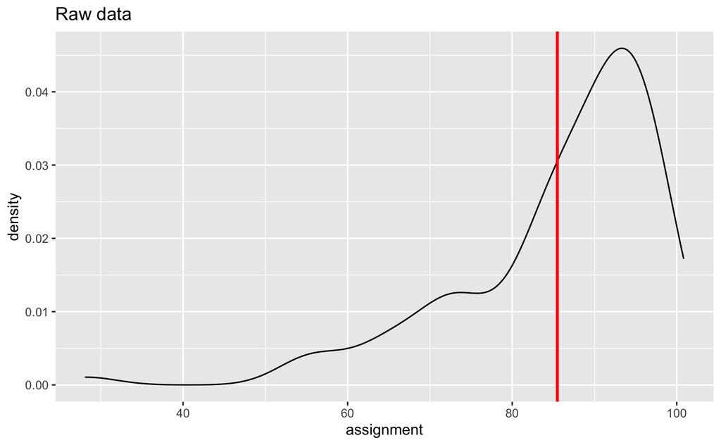

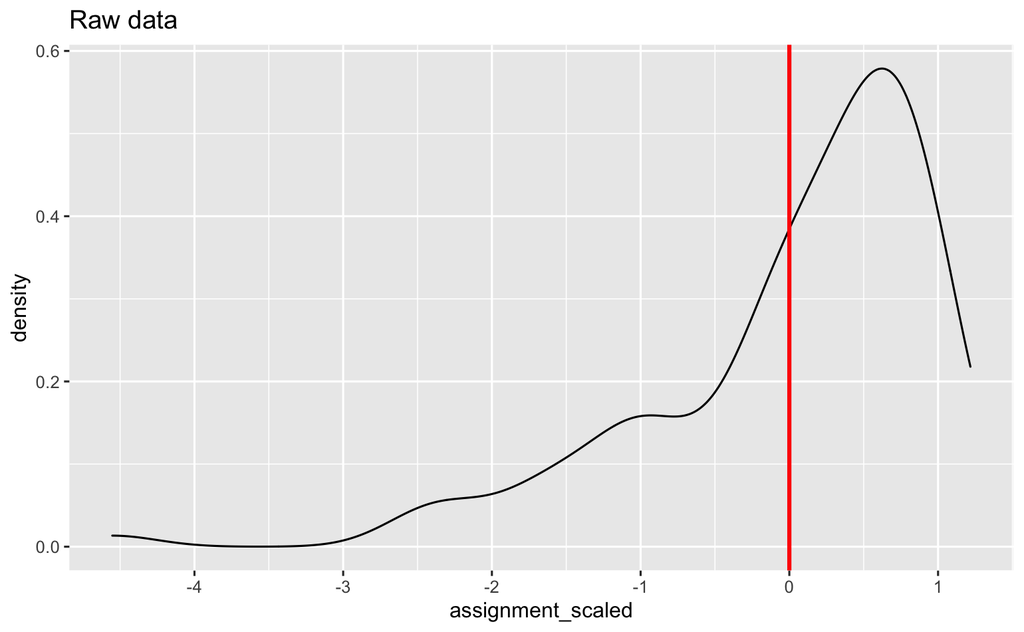

BREAK

# Multiple Linear Regression

As a reminder / sum, simple regression is using one variable to predict another. Multiple regression is using multiple variables to predict another variable

```r
library(mosaicData)
library(tidyverse)
library(janitor)
```

| hightemp | lowtemp | avgtemp | spring | summer | fall | cloudcover | precip | volume | weekday | dayType |
| --- | --- | --- | --- | --- | --- | --- | --- | --- | --- | --- |
| 83 | 50 | 66.5 | 0 | 1 | 0 | 7.6 | 0.00 | 501 | TRUE | weekday |
| 73 | 49 | 61.0 | 0 | 1 | 0 | 6.3 | 0.29 | 419 | TRUE | weekday |
| 74 | 52 | 63.0 | 1 | 0 | 0 | 7.5 | 0.32 | 397 | TRUE | weekday |
| 95 | 61 | 78.0 | 0 | 1 | 0 | 2.6 | 0.00 | 385 | FALSE | weekend |
| 44 | 52 | 48.0 | 1 | 0 | 0 | 10.0 | 0.14 | 200 | TRUE | weekday |
| 69 | 54 | 61.5 | 1 | 0 | 0 | 6.6 | 0.02 | 375 | TRUE | weekday |
| 66 | 39 | 52.5 | 1 | 0 | 0 | 2.4 | 0.00 | 417 | TRUE | weekday |
| 66 | 38 | 52.0 | 1 | 0 | 0 | 0.0 | 0.00 | 629 | FALSE | weekend |
| 80 | 55 | 67.5 | 0 | 1 | 0 | 3.8 | 0.00 | 533 | FALSE | weekend |
| 79 | 45 | 62.0 | 0 | 1 | 0 | 4.1 | 0.00 | 547 | TRUE | weekday |

[output cut: 80 more lines]

data needs cleaning

```r
railtrail_clean <- RailTrail %>%
  clean_names() %>%
  mutate(across(spring:fall, as.logical))

head(railtrail_clean)
```

|  | hightemp | lowtemp | avgtemp | spring | summer | fall | cloudcover | precip | volume | weekday | day_type |
| --- | --- | --- | --- | --- | --- | --- | --- | --- | --- | --- | --- |
| 1 | 83 | 50 | 66.5 | FALSE | TRUE | FALSE | 7.6 | 0.00 | 501 | TRUE | weekday |
| 2 | 73 | 49 | 61.0 | FALSE | TRUE | FALSE | 6.3 | 0.29 | 419 | TRUE | weekday |
| 3 | 74 | 52 | 63.0 | TRUE | FALSE | FALSE | 7.5 | 0.32 | 397 | TRUE | weekday |
| 4 | 95 | 61 | 78.0 | FALSE | TRUE | FALSE | 2.6 | 0.00 | 385 | FALSE | weekend |
| 5 | 44 | 52 | 48.0 | TRUE | FALSE | FALSE | 10.0 | 0.14 | 200 | TRUE | weekday |
| 6 | 69 | 54 | 61.5 | TRUE | FALSE | FALSE | 6.6 | 0.02 | 375 | TRUE | weekday |

```r
railtrail_trim <- railtrail_clean %>%
  select(-c("hightemp", "lowtemp", "fall", "day_type"))

head(railtrail_trim)
```

|  | avgtemp | spring | summer | cloudcover | precip | volume | weekday |
| --- | --- | --- | --- | --- | --- | --- | --- |
| 1 | 66.5 | FALSE | TRUE | 7.6 | 0.00 | 501 | TRUE |
| 2 | 61.0 | FALSE | TRUE | 6.3 | 0.29 | 419 | TRUE |
| 3 | 63.0 | TRUE | FALSE | 7.5 | 0.32 | 397 | TRUE |
| 4 | 78.0 | FALSE | TRUE | 2.6 | 0.00 | 385 | FALSE |
| 5 | 48.0 | TRUE | FALSE | 10.0 | 0.14 | 200 | TRUE |
| 6 | 61.5 | TRUE | FALSE | 6.6 | 0.02 | 375 | TRUE |

```r
alias(lm(volume ~ . , data = railtrail_clean))
```

```
Model :
volume ~ hightemp + lowtemp + avgtemp + spring + summer + fall +
    cloudcover + precip + weekday + day_type

Complete :
                (Intercept) hightemp lowtemp springTRUE summerTRUE cloudcover precip weekdayTRUE
avgtemp           0         1/2      1/2       0          0          0          0      0
fallTRUE          1           0        0      -1         -1          0          0      0
day_typeweekend   1           0        0       0          0          0          0     -1
```

[output not shown]

[output cut: 21 more lines]

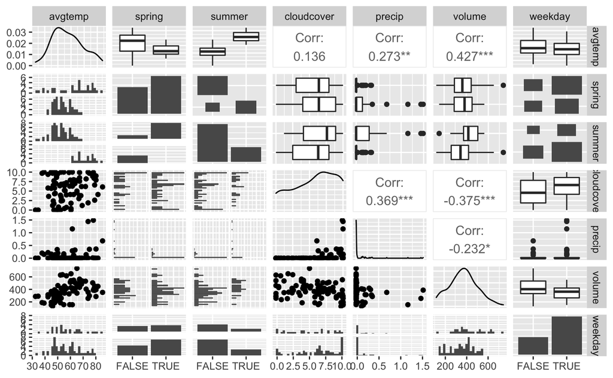

```r
ggpairs(railtrail_trim)
```

Making a model

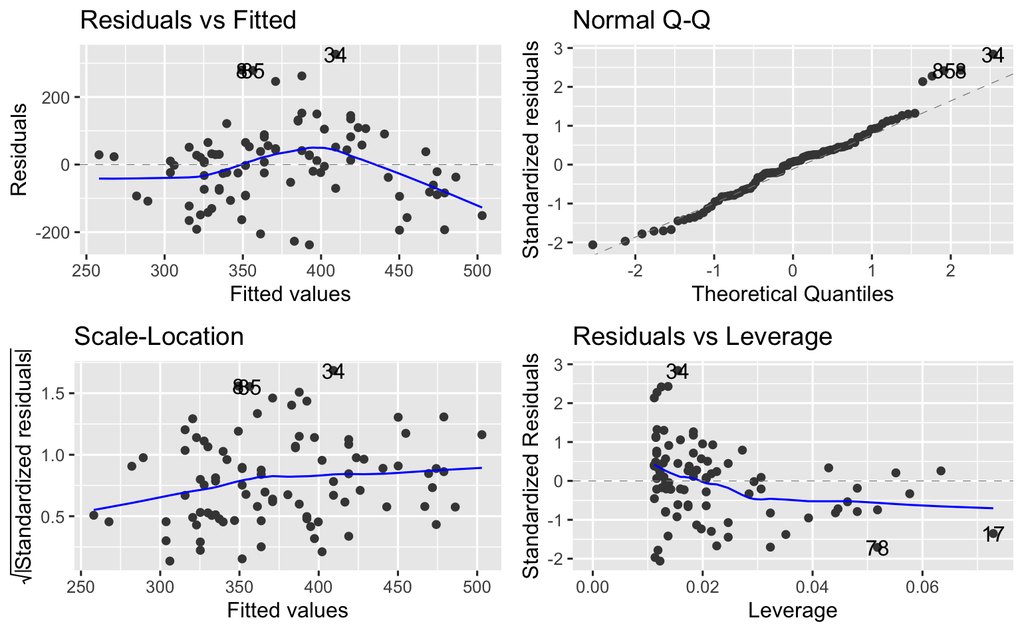

Not the best, but we’ll keep going

```r
summary(model)
```

```
Call:
lm(formula = volume ~ avgtemp, data = railtrail_trim)

Residuals:
    Min      1Q  Median      3Q     Max
-237.53  -80.00    8.49   55.14  326.67

Coefficients:
            Estimate Std. Error t value Pr(>|t|)
(Intercept)   99.602     63.474   1.569     0.12
avgtemp        4.802      1.084   4.428 2.72e-05 ***
---
Signif. codes:  0 ‘***’ 0.001 ‘**’ 0.01 ‘*’ 0.05 ‘.’ 0.1 ‘ ’ 1

Residual standard error: 115.9 on 88 degrees of freedom
Multiple R-squared:  0.1822,    Adjusted R-squared:  0.1729
F-statistic: 19.61 on 1 and 88 DF,  p-value: 2.723e-05
```

Task: Check the regression assumptions. How well does this simple model perform in predicting volume? [Hint - remember, we can check the regression assumptions by plotting the model object] What does the R-value tell us?

R-squared - is 18% variation is 18% So not very well!! (the higher the better; it can only account for 18%)

Add in another variable

```r
model2 <- lm(volume ~ avgtemp + weekday, data = railtrail_trim)

summary(model2)
```

```
Call:
lm(formula = volume ~ avgtemp + weekday, data = railtrail_trim)

Residuals:
    Min      1Q  Median      3Q     Max
-242.92  -75.72    3.15   66.90  280.06

Coefficients:
            Estimate Std. Error t value Pr(>|t|)
(Intercept)  163.022     65.428   2.492  0.01461 *
avgtemp        4.541      1.050   4.323 4.08e-05 ***
weekdayTRUE  -70.320     25.566  -2.751  0.00724 **
---
Signif. codes:  0 ‘***’ 0.001 ‘**’ 0.01 ‘*’ 0.05 ‘.’ 0.1 ‘ ’ 1

Residual standard error: 111.8 on 87 degrees of freedom
Multiple R-squared:  0.2476,    Adjusted R-squared:  0.2303
F-statistic: 14.32 on 2 and 87 DF,  p-value: 4.214e-06
```

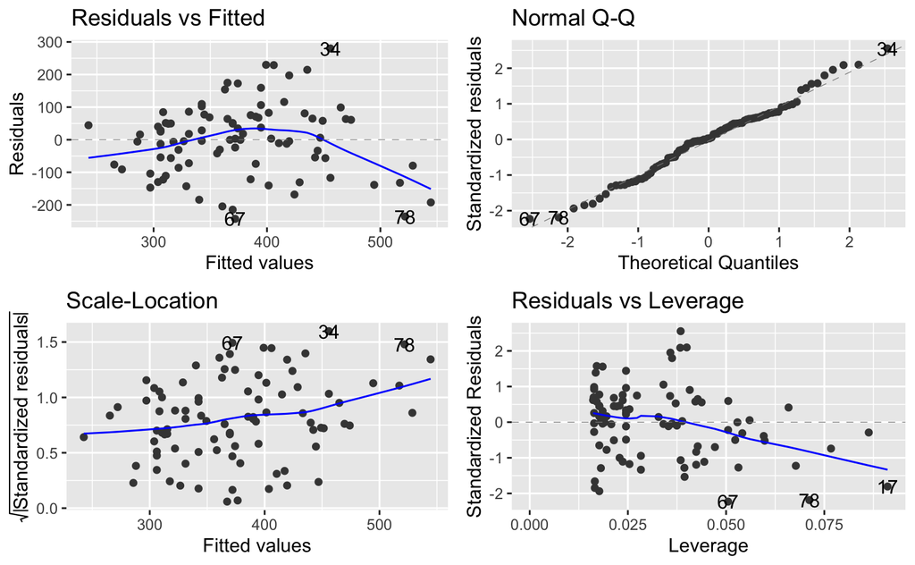

```r
autoplot(model2)
```

There are apprx 70 fewer users on the trail each weekday as compared with the weekend (with avg_temp held constant)

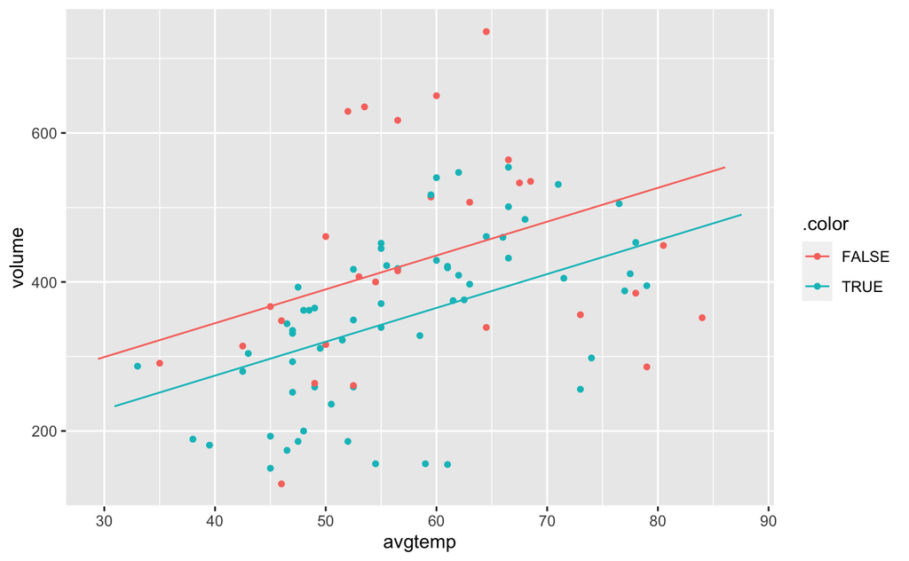

Task Adding summer as a categorical predictor

```r
summary(model3)
```

```
Call:
lm(formula = volume ~ avgtemp + weekday + summer, data = railtrail_trim)

Residuals:
     Min       1Q   Median       3Q      Max
-236.165  -75.448    6.184   68.496  252.680

Coefficients:
            Estimate Std. Error t value Pr(>|t|)
(Intercept)   71.376     90.336   0.790 0.431630
avgtemp        6.387      1.639   3.898 0.000192 ***
weekdayTRUE  -66.958     25.505  -2.625 0.010244 *
summerTRUE   -59.977     41.052  -1.461 0.147662
---
Signif. codes:  0 ‘***’ 0.001 ‘**’ 0.01 ‘*’ 0.05 ‘.’ 0.1 ‘ ’ 1

Residual standard error: 111.1 on 86 degrees of freedom
Multiple R-squared:  0.2659,    Adjusted R-squared:  0.2402
F-statistic: 10.38 on 3 and 86 DF,  p-value: 6.714e-06
```

# Interactions

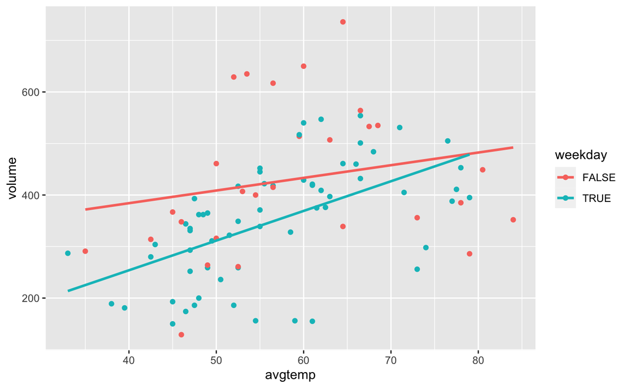

```r
railtrail_trim %>%
  ggplot(aes(x = avgtemp, y = volume, color = weekday)) +
  geom_point() +
  geom_smooth(method = "lm", se = FALSE)
```

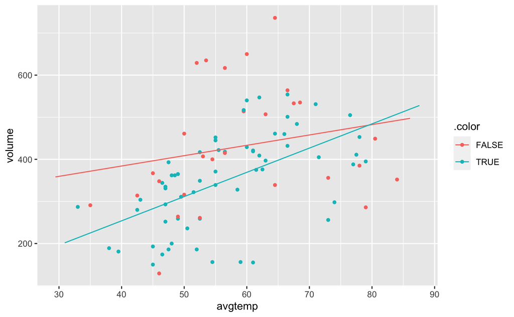

```r
model4 <- lm(volume ~ avgtemp + weekday + avgtemp:weekday , data = railtrail_trim)

plotModel(model4)
```

Examine summary

```r
summary(model4)
```

```
Call:
lm(formula = volume ~ avgtemp + weekday + avgtemp:weekday, data = railtrail_trim)

Residuals:
     Min       1Q   Median       3Q      Max
-269.906  -78.862    2.064   68.190  291.641

Coefficients:
                    Estimate Std. Error t value Pr(>|t|)
(Intercept)          285.887    103.390   2.765  0.00696 **
avgtemp                2.457      1.718   1.431  0.15619
weekdayTRUE         -262.193    128.181  -2.045  0.04386 *
avgtemp:weekdayTRUE    3.300      2.161   1.527  0.13040
---
Signif. codes:  0 ‘***’ 0.001 ‘**’ 0.01 ‘*’ 0.05 ‘.’ 0.1 ‘ ’ 1

Residual standard error: 111 on 86 degrees of freedom
Multiple R-squared:  0.2675,    Adjusted R-squared:  0.2419
F-statistic: 10.47 on 3 and 86 DF,  p-value: 6.115e-06
```

```r
summary(model5)
```

```
Call:
lm(formula = volume ~ avgtemp + weekday + cloudcover, data = railtrail_trim)

Residuals:
     Min       1Q   Median       3Q      Max
-204.803  -58.375    6.594   60.178  277.581

Coefficients:
            Estimate Std. Error t value Pr(>|t|)
(Intercept) 200.1022    59.1826   3.381  0.00109 **
avgtemp       5.2461     0.9536   5.502 3.81e-07 ***
weekdayTRUE -47.9480    23.4061  -2.049  0.04356 *
cloudcover  -16.0115     3.3952  -4.716 9.21e-06 ***
---
Signif. codes:  0 ‘***’ 0.001 ‘**’ 0.01 ‘*’ 0.05 ‘.’ 0.1 ‘ ’ 1

Residual standard error: 100.3 on 86 degrees of freedom
Multiple R-squared:  0.4022,    Adjusted R-squared:  0.3814
F-statistic: 19.29 on 3 and 86 DF,  p-value: 1.185e-09
```

Interpretation is that: For every 1 fahr increase (1 unit), there are 5.2 more users

Check this in notes (re-read)

Task Add precip (daily precipitation in inches) into the regression model. Perform diagnostics, and if you find that precip is a significant predictor, interpret its fitted coefficient.

```r
model6 <- lm(volume ~ avgtemp + weekday + cloudcover + precip, data = railtrail_trim)

summary(model6)
```

```
Call:
lm(formula = volume ~ avgtemp + weekday + cloudcover + precip,
    data = railtrail_trim)

Residuals:
     Min       1Q   Median       3Q      Max
-218.881  -58.924    3.428   57.285  266.250

Coefficients:
             Estimate Std. Error t value Pr(>|t|)
(Intercept)  155.0024    59.4574   2.607 0.010787 *
avgtemp        5.8743     0.9485   6.193 2.02e-08 ***
weekdayTRUE  -45.8821    22.5943  -2.031 0.045412 *
cloudcover   -12.8294     3.4783  -3.688 0.000397 ***
precip      -117.5681    43.2329  -2.719 0.007928 **
---
Signif. codes:  0 ‘***’ 0.001 ‘**’ 0.01 ‘*’ 0.05 ‘.’ 0.1 ‘ ’ 1

Residual standard error: 96.72 on 85 degrees of freedom
Multiple R-squared:  0.4501,    Adjusted R-squared:  0.4242
F-statistic: 17.39 on 4 and 85 DF,  p-value: 1.849e-10
```

# Interactions of continuous predictors

predictors = variable (it’s the same thing)

```r
model7 <- lm(volume ~ avgtemp + cloudcover + weekday + precip + avgtemp:precip, data = railtrail_trim)
summary(model7)
```

```
Call:
lm(formula = volume ~ avgtemp + cloudcover + weekday + precip +
    avgtemp:precip, data = railtrail_trim)

Residuals:
     Min       1Q   Median       3Q      Max
-218.775  -59.164    3.183   57.361  266.189

Coefficients:
                Estimate Std. Error t value Pr(>|t|)
(Intercept)     153.9280    63.9007   2.409 0.018189 *
avgtemp           5.8964     1.0598   5.564 3.08e-07 ***
cloudcover      -12.8866     3.6984  -3.484 0.000786 ***
weekdayTRUE     -45.8527    22.7365  -2.017 0.046921 *
precip         -100.8213   353.3547  -0.285 0.776097
avgtemp:precip   -0.2335     4.8893  -0.048 0.962023
---
Signif. codes:  0 ‘***’ 0.001 ‘**’ 0.01 ‘*’ 0.05 ‘.’ 0.1 ‘ ’ 1

Residual standard error: 97.29 on 84 degrees of freedom
Multiple R-squared:  0.4501,    Adjusted R-squared:  0.4173
F-statistic: 13.75 on 5 and 84 DF,  p-value: 8.34e-10
```

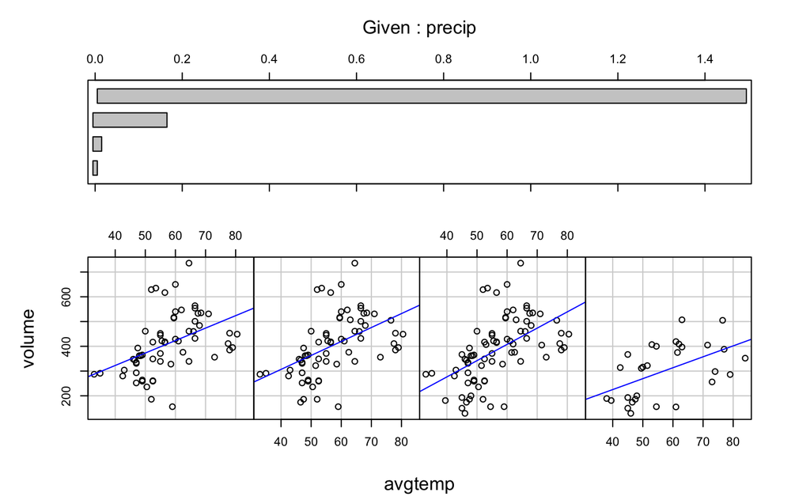